# 第2章: 単回帰モデル

Jeffrey Wooldridge (2016). Introductory Econometrics: A Modern Approach Seventh Edition. Cengage Learning.

2026-01-23

# 準備

# 必要なパッケージの読み込み

- `wooldridge`パッケージの読み込み

```r
library(wooldridge)
```

- 今回は`ggplot2`も使用してグラフを描画（オプション）

```r
library(ggplot2)
```

# 2-1 単回帰モデルの定義

# 単回帰モデル

- **単回帰モデル**（simple regression model）は、2つの変数 $x$ と $y$ の関係を以下のように定義する。

$$y = \beta_0 + \beta_1 x + u$$

- $y$: **従属変数**（dependent variable）、被説明変数、目的変数
- $x$: **独立変数**（independent variable）、説明変数、共変量
- $u$: **誤差項**（error term）、撹乱項
- $\beta_0$: **切片パラメータ**（intercept parameter）
- $\beta_1$: **傾きパラメータ**（slope parameter）

# 誤差項 $u$ について

- 誤差項 $u$ は、$y$ に影響を与える $x$ 以外のすべての要因を表す。
- 単回帰分析の主な目的は、他の要因（$u$ に含まれる要因）を一定に保ったまま（ceteris paribus）、$x$ が $y$ に与える効果 $\beta_1$ を推定することである。
- しかし、$x$ と $u$ に相関がある場合、因果関係の解釈は難しくなる。

# ゼロ条件付き平均の仮定

- 因果関係を識別するための重要な仮定は、$x$ の値が与えられたときの $u$ の平均値が0であることである。

$$E(u|x) = 0$$

- この仮定は、$x$ と $u$ が無相関であることを意味する。
- この仮定が満たされるとき、**母回帰関数**（Population Regression Function: PRF）は以下のようになる。

$$E(y|x) = \beta_0 + \beta_1 x$$

# 2-2 通常最小二乗法（OLS）の導出

# OLS推定量

- 未知のパラメータ $\beta_0, \beta_1$ を、データの標本 $\{(x_i, y_i): i=1, ..., n\}$ を用いて推定する。
- **残差**（residual）$\hat{u}_i$ を以下のように定義する。

$$\hat{u}_i = y_i - \hat{\beta}_0 - \hat{\beta}_1 x_i$$

- **残差二乗和**（Sum of Squared Residuals: SSR）を最小化するように $\hat{\beta}_0, \hat{\beta}_1$ を決定する方法を**通常最小二乗法**（Ordinary Least Squares: OLS）と呼ぶ。

$$\min_{\hat{\beta}_0, \hat{\beta}_1} \sum_{i=1}^n (y_i - \hat{\beta}_0 - \hat{\beta}_1 x_i)^2$$

# OLS推定量の公式

- OLS推定量 $\hat{\beta}_1$ と $\hat{\beta}_0$ は以下の式で計算される。

$$\hat{\beta}_1 = \frac{\sum_{i=1}^n (x_i - \bar{x})(y_i - \bar{y})}{\sum_{i=1}^n (x_i - \bar{x})^2} = \frac{\text{Cov}(x, y)}{\text{Var}(x)}$$

$$\hat{\beta}_0 = \bar{y} - \hat{\beta}_1 \bar{x}$$

- ここで、$\bar{x}, \bar{y}$ はそれぞれ標本平均である。

# 2-3 Rによる単回帰分析の実装

# 例: CEOの給与と自己資本利益率 (`ceosal1`)

- `ceosal1` データセットを使用して、CEOの給与（`salary`）と企業の自己資本利益率（`roe`）の関係を分析する。

$$salary = \beta_0 + \beta_1 roe + u$$

# データの確認

```r
# データの読み込みと確認
data(ceosal1)
head(ceosal1[, c("salary", "roe")])
```

```
##   salary  roe
## 1   1095 14.1
## 2   1001 10.9
## 3   1122 23.5
## 4    578  5.9
## 5   1368 13.8
## 6   1145 20.0
```

# 回帰分析の実行 (`lm`関数)

- Rでは `lm()` 関数（Linear Model）を使用して回帰分析を行う。

```r
# 単回帰分析の実行
model_ceo <- lm(salary ~ roe, data = ceosal1)
```

```r
# 結果の要約を表示
summary(model_ceo)
```

```
##
## Call:
## lm(formula = salary ~ roe, data = ceosal1)
##
## Residuals:
##     Min      1Q  Median      3Q     Max
## -1160.2  -526.0  -254.0   138.8 13499.9
##
## Coefficients:
##             Estimate Std. Error t value Pr(>|t|)
## (Intercept)   963.19     213.24   4.517 1.05e-05 ***
## roe            18.50      11.12   1.663   0.0978 .
## ---
## Signif. codes:  0 '***' 0.001 '**' 0.01 '*' 0.05 '.' 0.1 ' ' 1
##
## Residual standard error: 1367 on 207 degrees of freedom
## Multiple R-squared:  0.01319,    Adjusted R-squared:  0.008421
## F-statistic: 2.767 on 1 and 207 DF,  p-value: 0.09777
```

# 結果の解釈

- 推定された回帰式は以下の通り。

$$\widehat{salary} = 963.19 + 18.50 \cdot roe$$

- 切片 963.19 は、$roe=0$ のときの平均給与（千ドル）を表す。
- 傾き 18.50 は、$roe$ が1ポイント上昇すると、給与が平均で18.5千ドル（1万8500ドル）増加することを意味する。

# 散布図と回帰直線のプロット

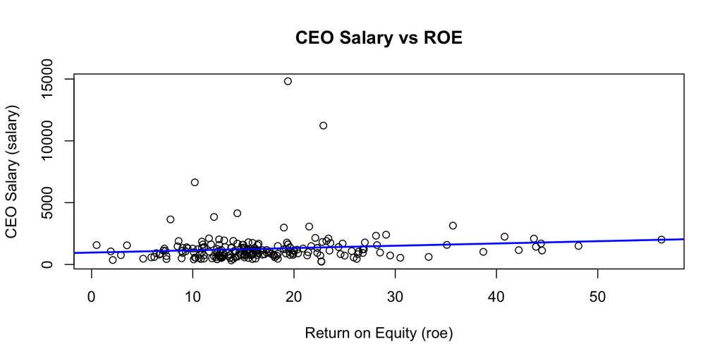

```r
plot(ceosal1$roe, ceosal1$salary,
     xlab = "Return on Equity (roe)",
     ylab = "CEO Salary (salary)",
     main = "CEO Salary vs ROE")
abline(model_ceo, col = "blue", lwd = 2)
```

# 2-4 適合度と決定係数

# 決定係数 ($R^2$)

- **決定係数**（R-squared）は、従属変数の変動のうち、独立変数によって説明される割合を示す。

$$R^2 = \frac{\text{SSE}}{\text{SST}} = 1 - \frac{\text{SSR}}{\text{SST}}$$

- SSE (Explained Sum of Squares): 回帰変動
- SSR (Residual Sum of Squares): 残差変動
- SST (Total Sum of Squares): 全変動
- $0 \le R^2 \le 1$ であり、1に近いほどモデルの当てはまりが良いとされるが、低いからといってモデルが無意味なわけではない。

# `ceosal1` の $R^2$

- 先ほどの分析結果（`summary(model_ceo)`）を見ると、`Multiple R-squared: 0.01319` となっている。
- これは、CEOの給与の変動の約1.3%しか `roe` で説明できていないことを意味する。
- 給与には `roe` 以外の多くの要因が影響していることが示唆される。

# 2-5 関数形：対数を用いたモデル

# 対数モデルの利点

- 変数を対数変換（log）することで、非線形な関係を線形モデルとして扱うことができる。
- 係数の解釈が「変化量」から「変化率（%）」に変わる。

| モデル | 方程式 | 解釈 |
| --- | --- | --- |
| Level-level | $y = \beta_0 + \beta_1 x$ | $\Delta y = \beta_1 \Delta x$ |
| Log-level | $\log(y) = \beta_0 + \beta_1 x$ | $\% \Delta y \approx (100 \beta_1) \Delta x$ |
| Level-log | $y = \beta_0 + \beta_1 \log(x)$ | $\Delta y \approx (\beta_1 / 100) \% \Delta x$ |
| Log-log | $\log(y) = \beta_0 + \beta_1 \log(x)$ | $\% \Delta y \approx \beta_1 \% \Delta x$ (弾力性) |

# 例: 賃金方程式 (`wage1`)

- 賃金（`wage`）の対数をとり、教育年数（`educ`）で回帰する（Log-levelモデル）。

$$\log(wage) = \beta_0 + \beta_1 educ + u$$

```r
data(wage1)
# 対数賃金の回帰分析
model_wage <- lm(log(wage) ~ educ, data = wage1)
```

```r
summary(model_wage)$coefficients
```

```
##               Estimate  Std. Error  t value     Pr(>|t|)
## (Intercept) 0.58377267 0.097335834  5.99751 3.736702e-09
## educ        0.08274437 0.007566694 10.93534 3.270645e-25
```

# 結果の解釈（賃金方程式）

$$\widehat{\log(wage)} = 0.584 + 0.083 \cdot educ$$

- $\beta_1 = 0.083$
- これは、教育年数が1年増えると、賃金が約 $8.3\%$ 増加することを意味する（**教育の収益率**）。
- $100 \times 0.083 = 8.3\%$

# まとめ

# まとめ

- 単回帰モデルは、2変数間の線形関係を分析する基本的な手法である。
- OLS（最小二乗法）は、残差二乗和を最小化することでパラメータを推定する。
- $R^2$（決定係数）はモデルの当てはまりの良さを測る指標である。
- 対数変換を用いることで、弾力性や成長率（%変化）として係数を解釈できる。